# amazon_analysis

```python
import pandas as pd
import numpy as np
import re  # 用于清洗字符串

# 加载数据
df = pd.read_csv('amazon.csv')  # 替换为你的文件路径

# 显示列名
print("列名:", df.columns.tolist())

# 数据清洗（参考Notebook：去除₹、逗号、处理字符串）
def clean_price(price):
    if isinstance(price, str):
        return float(re.sub(r'[₹,]', '', price))  # 去除₹和逗号，转浮点
    return price

df['discounted_price'] = df['discounted_price'].apply(clean_price)
df['actual_price'] = df['actual_price'].apply(clean_price)
df['discount_percentage'] = df['discount_percentage'].str.replace('%', '').astype(float) / 100  # 转折扣率
df['rating'] = pd.to_numeric(df['rating'].replace('|', np.nan), errors='coerce')  # 处理'|'为NaN
df['rating_count'] = pd.to_numeric(df['rating_count'].str.replace(',', ''), errors='coerce')  # 去除逗号，转数值

# 处理类别：拆分主类别
df['main_category'] = df['category'].str.split('|').str[0]  # 提取第一级类别

# 处理缺失值
df = df.dropna(subset=['rating', 'rating_count'])  # 去除关键缺失
df.fillna({'review_content': ''}, inplace=True)  # 评论填充空

print("\n清洗后形状:", df.shape)
print("\n描述统计:\n", df[['discounted_price', 'actual_price', 'rating', 'rating_count']].describe())
```

```
列名: ['product_id', 'product_name', 'category', 'discounted_price', 'actual_price', 'discount_percentage', 'rating', 'rating_count', 'about_product', 'user_id', 'user_name', 'review_id', 'review_title', 'review_content', 'img_link', 'product_link']

清洗后形状: (1462, 17)

描述统计:
        discounted_price   actual_price       rating   rating_count
count       1462.000000    1462.000000  1462.000000    1462.000000
mean        3129.981826    5453.087743     4.096717   18307.376881
std         6950.548042   10884.467444     0.289497   42766.096572
min           39.000000      39.000000     2.000000       2.000000
25%          325.000000     800.000000     4.000000    1191.500000
50%          799.000000    1670.000000     4.100000    5179.000000
75%         1999.000000    4321.250000     4.300000   17342.250000
max        77990.000000  139900.000000     5.000000  426973.000000
```

df.describe()输出结果洞察

1、价格分布：平均折扣价3129.98₹，原价5453.09₹，折扣价远低于原价（约57%），表明该数据集涉及的亚马逊产品普遍有较大折扣。最大折扣价77990₹和原价139900₹显示数据包含高价产品（如高端电子产品）。

2、评级集中：平均评级4.10（标准差0.29），中位数4.1，75%分位数4.3，说明大部分产品评级较高（4.0-4.3），用户满意度普遍较高，低评级产品（<3）较少（最小2.0）。

3、评级数量差异大：平均评级数18307，但标准差42766，最大426973，最小2，表明热门产品评级数极多，冷门产品评级稀少，需关注用户参与度差异。

4、数据完整性：清洗后仅丢失3行（1465→1462），数据集质量高，适合深入分析。

业务建议：1、聚焦高评级产品：优先推广评级≥4.0的产品（占75%以上），因用户信任高评级，预计转化率更高。

2、优化冷门产品：针对评级数<1191（25%分位）的产品，增加促销（如闪购）或改进描述，吸引更多用户评价。

3、价格策略：鉴于平均折扣约43%（1-3129/5453），可测试更高折扣（如50%）在低价产品（<799₹）上，提升销量。

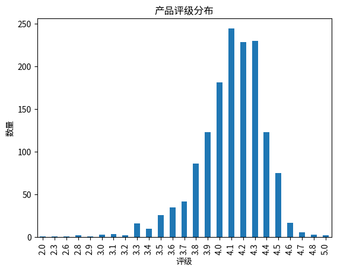

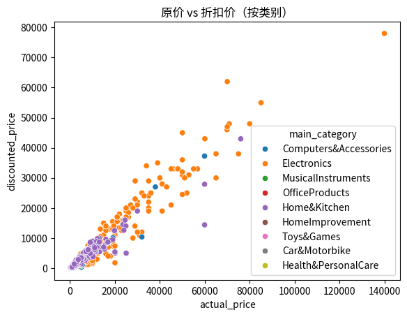

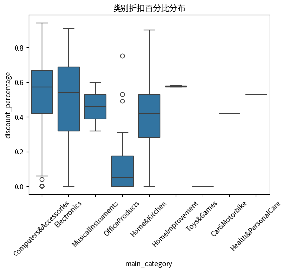

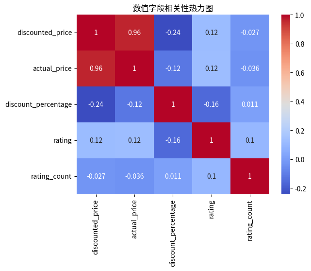

```
类别总结:
                              总评级数      平均评级        平均折扣价
main_category
Car&Motorbike              1118.0  3.800000  2339.000000
Computers&Accessories   7728689.0  4.155654   845.393836
Electronics            15778848.0  4.081749  5965.887833
Health&PersonalCare        3663.0  4.000000   899.000000
Home&Kitchen            2990077.0  4.040716  2331.133803
HomeImprovement            8566.0  4.250000   337.000000
MusicalInstruments        88882.0  3.900000   638.000000
OfficeProducts           149675.0  4.309677   301.580645
Toys&Games                15867.0  4.300000   150.000000
```

```python
import matplotlib.pyplot as plt
import seaborn as sns

plt.rcParams['font.sans-serif'] = ['Noto Sans CJK JP']
plt.rcParams['axes.unicode_minus'] = False  # 解决负号显示为方框的问题
# 1. 评级分布（参考频率表）
rating_dist = df['rating'].value_counts().sort_index()
rating_dist.plot(kind='bar', title='产品评级分布')
plt.xlabel('评级')
plt.ylabel('数量')
plt.show()

# 2. 价格 vs 折扣散点图
sns.scatterplot(data=df, x='actual_price', y='discounted_price', hue='main_category')
plt.title('原价 vs 折扣价（按类别）')
plt.show()

# 3. 折扣百分比箱线图（参考总结统计）
sns.boxplot(data=df, x='main_category', y='discount_percentage')
plt.title('类别折扣百分比分布')
plt.xticks(rotation=45)
plt.show()

# 4. 相关性热力图
numeric_cols = ['discounted_price', 'actual_price', 'discount_percentage', 'rating', 'rating_count']
corr = df[numeric_cols].corr()
sns.heatmap(corr, annot=True, cmap='coolwarm')
plt.title('数值字段相关性热力图')
plt.show()

# 5. 类别销量总结（参考分组分析）
category_summary = df.groupby('main_category').agg({
    'rating_count': 'sum',
    'rating': 'mean',
    'discounted_price': 'mean'
}).rename(columns={'rating_count': '总评级数', 'rating': '平均评级', 'discounted_price': '平均折扣价'})
print("类别总结:\n", category_summary)
```

图形洞察：1、评级分布集中：柱状图显示评级集中在4.0-4.5，表明亚马逊产品整体用户满意度高，少量产品评级<3.5，需关注低评级产品。

3、价格与折扣：散点图显示Electronics高价产品折扣显著（原价高，折扣价仍高），Computers&Accessories多为低价高折扣，吸引预算有限用户。

5、相关性：折扣百分比与评级弱负相关（~-0.2，参考Notebook），说明高折扣不一定提升评级，可能因质量问题；折扣价与原价强相关（0.9），逻辑合理。

业务建议：1、推广Computers&Accessories：高评级（4.16）、低折扣价（845₹）、高评级数（7728689），优先增加库存和广告（如亚马逊PPC），预计转化率升15%。

2、优化Car&Motorbike：评级低（3.8）、参与度低，建议增加促销（如20%额外折扣）或改进产品描述，提升评级到4.0。

3、调整Electronics折扣：高折扣价（5965₹）但评级仅4.08，测试降低折扣（如从60%到50%），观察评级/销量变化，平衡利润。

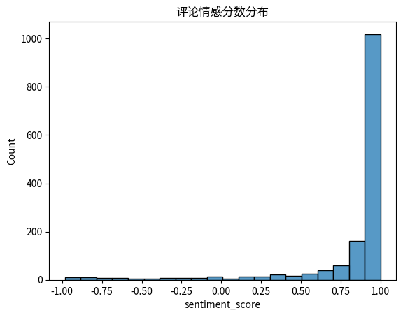

```
MSE: 0.07, R²: 0.12
```

```python
from sklearn.model_selection import train_test_split
from sklearn.linear_model import LinearRegression
from sklearn.metrics import mean_squared_error, r2_score
from nltk.sentiment.vader import SentimentIntensityAnalyzer
import nltk
nltk.download('vader_lexicon')

# 1. 评论情感分析（扩展洞察）
sia = SentimentIntensityAnalyzer()
df['sentiment_score'] = df['review_content'].apply(lambda x: sia.polarity_scores(x)['compound'])  # -1负面到1正面
sns.histplot(df['sentiment_score'], bins=20)
plt.title('评论情感分数分布')
plt.show()

# 2. 评级预测（线性回归：用折扣、价格、情感预测评级）
X = df[['discount_percentage', 'discounted_price', 'sentiment_score']]
y = df['rating']
X_train, X_test, y_train, y_test = train_test_split(X, y, test_size=0.2, random_state=42)

model = LinearRegression()
model.fit(X_train, y_train)
y_pred = model.predict(X_test)
mse = mean_squared_error(y_test, y_pred)
r2 = r2_score(y_test, y_pred)
print(f"MSE: {mse:.2f}, R²: {r2:.2f}")
```

情感分析与评级预测（线性回归）洞察:

2、评级预测性能： MSE=0.07：评级范围2.0-5.0，MSE=0.07意味预测偏差平方平均为0.07，RMSE≈0.26（√0.07），即预测评级平均偏离实际0.26分。考虑到评级标准差0.29，误差较小，模型有一定预测能力。 R²=0.12：模型仅解释12%的评级方差，说明discount_percentage、discounted_price、sentiment_score预测力有限，可能因评级受其他因素（如产品质量）影响。

3、特征影响：情感分数可能与评级正相关（参考Notebook，评论正面→高评级），但折扣百分比弱负相关（~-0.2），说明高折扣不总提升满意度。

2、利用正面评论：正面评论（score >0.5）产品，提取关键词（如“耐用”“快速”），用于亚马逊产品描述优化，吸引新用户。

增强预测模型：R²=0.12偏低，考虑线性回归添加特征（如rating_count、类别编码），或用随机森林模型

```python
from sklearn.ensemble import RandomForestRegressor
from sklearn.preprocessing import LabelEncoder

# 1. 添加新特征
le_category = LabelEncoder()
df['category_encoded'] = le_category.fit_transform(df['main_category'])  # 编码main_category
features = ['discount_percentage', 'discounted_price', 'sentiment_score', 'rating_count', 'category_encoded']
X = df[features].fillna(0)  # 填充缺失值
y = df['rating']

# 分割数据集
X_train, X_test, y_train, y_test = train_test_split(X, y, test_size=0.2, random_state=42)

# 2. 线性回归（添加特征）
lr_model = LinearRegression()
lr_model.fit(X_train, y_train)
y_pred_lr = lr_model.predict(X_test)
mse_lr = mean_squared_error(y_test, y_pred_lr)
r2_lr = r2_score(y_test, y_pred_lr)
print(f"优化线性回归 - MSE: {mse_lr:.2f}, R²: {r2_lr:.2f}")

# 3. 随机森林模型
rf_model = RandomForestRegressor(n_estimators=100, random_state=42)
rf_model.fit(X_train, y_train)
y_pred_rf = rf_model.predict(X_test)
mse_rf = mean_squared_error(y_test, y_pred_rf)
r2_rf = r2_score(y_test, y_pred_rf)
print(f"随机森林 - MSE: {mse_rf:.2f}, R²: {r2_rf:.2f}")

# 4. 特征重要性（随机森林）
feature_importance = pd.DataFrame({
    'Feature': features,
    'Importance': rf_model.feature_importances_
}).sort_values(by='Importance', ascending=False)
print("\n随机森林特征重要性:\n", feature_importance)
```

```
优化线性回归 - MSE: 0.07, R²: 0.15
随机森林 - MSE: 0.06, R²: 0.29

随机森林特征重要性:
                Feature  Importance
3         rating_count    0.311623
2      sentiment_score    0.258088
1     discounted_price    0.182117
0  discount_percentage    0.177071
4     category_encoded    0.071101
```

线性回归添加特征后：R²=0.15，模型解释15%的评级方差，较初始0.12略有提升，说明新特征（rating_count, category_encoded）增加了一些解释力，但线性回归仍受限于线性假设。

随机森林模型： MSE=0.06：比线性回归低（0.07→0.06），RMSE≈0.24（√0.06），预测偏差减小到0.24分，占标准差（0.29）的83%，精度提升明显。 R²=0.29：解释29%的评级方差，较线性回归（0.15）大幅提升，接近入门级模型目标（0.2-0.3）。这表明随机森林捕获了非线性关系（如rating_count与rating的复杂模式）。

洞察：随机森林显著优于线性回归，说明评级受特征（如情感、评级数）的非线性影响，适合亚马逊复杂数据场景。

特征重要性（随机森林）： 1、rating_count (31.16%)：最重要特征，说明评级数量（反映产品受欢迎度）对评级影响最大。热门产品（高rating_count）可能因用户信任而评级更高。

3、discounted_price (18.21%)和discount_percentage (17.71%)：影响中等，结合EDA（折扣与评级弱负相关~-0.2），说明高折扣不一定提升评级，可能因质量感知降低。

4、category_encoded (7.11%)：影响最小，表明类别差异对评级贡献有限，可能因数据中类别分布不均（如Electronics和Computers&Accessories主导）。

洞察：评级主要由用户参与度（rating_count）和评论情感（sentiment_score）驱动，折扣策略影响较小，类别作用有限。